# Health Index

```r
#====== Cluster binarios (sim/nao) ========#

#Criar metadados binários para fazer kmeans (distância euclideana) e pcoa

metadados_upset <- metadados.all.filtrado %>%
  mutate(
    High_Triglycerides = ifelse(!is.na(Triglycerides) & Triglycerides > 150, 1, 0),
    High_Fasting_Glucose = ifelse(!is.na(Glucose) & Glucose > 100, 1, 0),
    Obesity = ifelse(BMI >= 30, 1, 0),  # BMI tem 0 NA, sem ifelse extra
    Low_HDL = ifelse(!is.na(HDL) & HDL < 40, 1, 0),
    High_Blood_Pressure = ifelse(!is.na(Systolic) & !is.na(Diastolic) &
                                   (Systolic >= 130 | Diastolic >= 85), 1, 0)
  )
```

[output not shown]

```r
#=====================================================#

#       Score metabolico

#=====================================================#


#Criar metadados binários para fazer kmeans (distância euclideana) e pcoa

metadados_grupos_saude_binario <- metadados.all.filtrado %>%
  mutate(
    # Pressão arterial
    High_Blood_Pressure = ifelse(!is.na(Systolic) & !is.na(Diastolic) &
                                   (Systolic >= 130 | Diastolic >= 85), 1, 0),

    # Glucose de jejum
    High_Fasting_Glucose = case_when(
      is.na(Glucose) ~ NA_integer_,
      Glucose <= 100 ~ 0,                 # normal
      Glucose > 100 & Glucose < 126 ~ 1,  # alterada (pré-diabetes)
      Glucose >= 126 ~ 2                  # muito alta (diabetes)
    ),

    # HbA1c em porcentagem
    HbA1c_cat = case_when(
      is.na(HbA1c) ~ NA_integer_,
      HbA1c < 6.0 ~ 0,
      HbA1c >= 6.0 & HbA1c < 6.5 ~ 1,
      HbA1c >= 6.5 ~ 2
    ),


    # BMI categorizado por faixa etária
    BMI_cat = case_when(
      is.na(BMI) | is.na(Age) ~ NA_integer_,
      Age >= 60 & BMI < 22 ~ 1,
      Age >= 60 & BMI >= 22 & BMI < 27 ~ 0,
      Age >= 60 & BMI >= 27 & BMI < 30 ~ 1,
      Age >= 60 & BMI >= 30 & BMI < 35 ~ 2,
      Age >= 60 & BMI >= 35 ~ 3,
      Age < 60 & BMI < 18.5 ~ 1,
      Age < 60 & BMI >= 18.5 & BMI < 25 ~ 0,
      Age < 60 & BMI >= 25 & BMI < 30 ~ 1,
      Age < 60 & BMI >= 30 & BMI < 35 ~ 2,
      Age < 60 & BMI >= 35 & BMI < 40 ~ 3,
      Age < 60 & BMI >= 40 ~ 4
    ),

    # Triglicerídeos
    TRIG_cat = case_when(
      is.na(Triglycerides) ~ NA_integer_,
      Triglycerides < 150 ~ 0,
      Triglycerides >= 150 & Triglycerides < 200 ~ 1,
      Triglycerides >= 200 & Triglycerides < 500 ~ 2,
      Triglycerides >= 500 ~ 3
    ),

    # Cholesterol total
    COL_cat = case_when(
      is.na(Cholesterol) ~ NA_integer_,
      Cholesterol <= 190 ~ 0,
      Cholesterol > 190 & Cholesterol <= 240 ~ 1,
      Cholesterol > 240 ~ 2
    ),


    # HDL
    HDL_cat = case_when(
      is.na(HDL) ~ NA_integer_,
      HDL < 40 ~ 1,        # risco
      HDL >= 40 ~ 0 ),       # normal ou bom



    # LDL
    LDL_cat = case_when(
      is.na(LDL) ~ NA_integer_,
      LDL < 100 ~ 0,
      LDL >= 100 & LDL < 130 ~ 0,
      LDL >= 130 & LDL < 160 ~ 1,
      LDL >= 160 & LDL < 190 ~ 2,
      LDL >= 190 ~ 3
    ),

    # GGT por sexo
    GGT_cat = case_when(
      is.na(GGT) | is.na(Sex) ~ NA_integer_,
      Sex == "Masculino" & GGT <= 48 ~ 0,
      Sex == "Masculino" & GGT > 48 ~ 1,
      Sex == "Feminino" & GGT <= 32 ~ 0,
      Sex == "Feminino" & GGT > 32 ~ 1
    )
  )
```

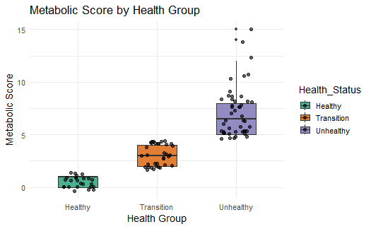

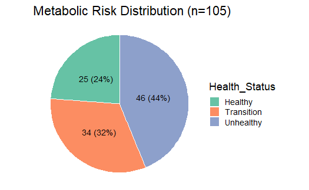

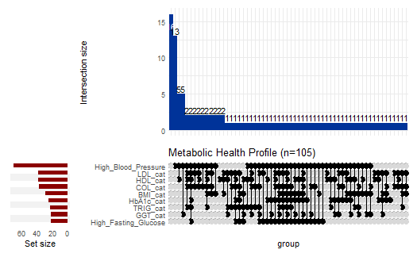

```
[1] "IL17A - p = 0.6381"
[1] "IFNGamma - p = 0.4063"
[1] "TNF - p = 0.5907"
[1] "IL10 - p = 0.7533"
[1] "IL6 - p = 0.9102"
[1] "IL4 - p = 0.4557"
[1] "IL2 - p = 0.1292"
```

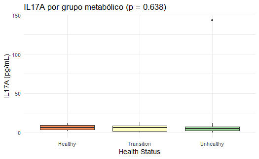

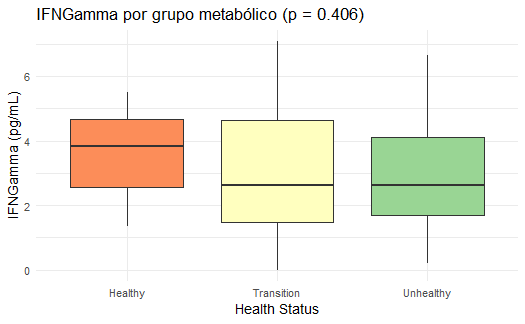

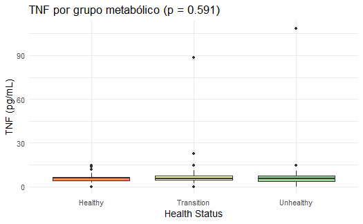

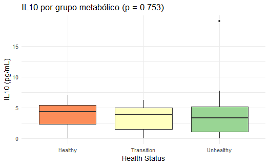

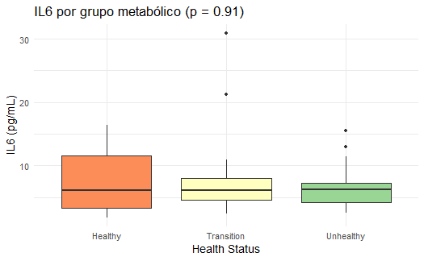

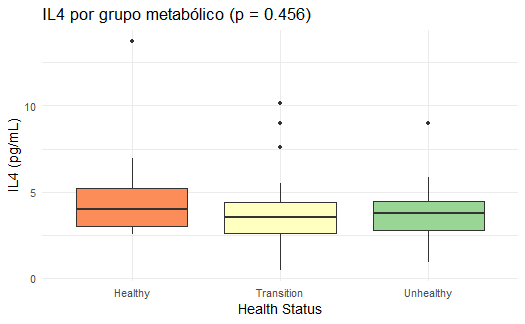

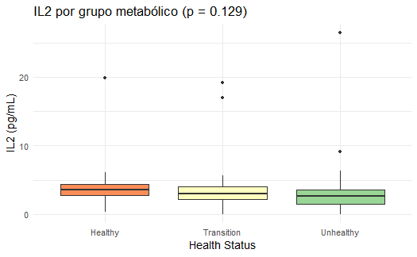

```r
# Loop para gerar boxplots + Kruskal
for (cit in citocinas) {
  dados <- metadados_grupos_saude_binario[, c("Health_Status", cit)]
  dados <- dados[!is.na(dados[[cit]]), ]  # remove NAs da citocina

  # Teste de Kruskal
  p.kruskal <- kruskal.test(reformulate("Health_Status", cit), data = dados)
  print(paste(cit, "- p =", round(p.kruskal$p.value, 4)))

  # Gráfico
  p2 <- ggplot(dados, aes(x = Health_Status, y = .data[[cit]], fill = Health_Status)) +
    geom_boxplot() +
    labs(title = paste0(cit, " por grupo metabólico (p = ", round(p.kruskal$p.value, 3), ")"),
         x = "Health Status", y = paste(cit, "(pg/mL)")) +
    theme_minimal(base_size = 14) +
    scale_fill_brewer(palette = "Spectral") +
    theme(legend.position = "none")

  print(p2)
}
```

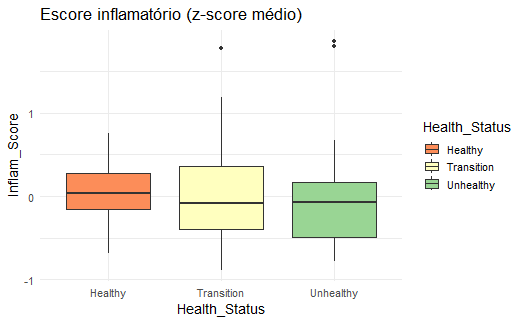

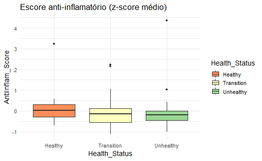

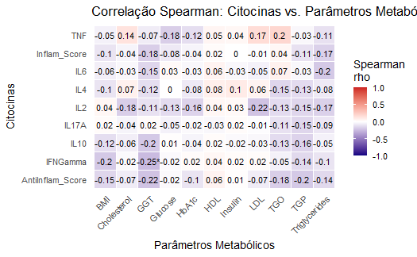

```r
# 2. Loop para cada par (citocina x índice de diversidade)
for (cytokine in citocinas) {
  for (alpha in alphas) {

    # Remover NA dos dois vetores
    dados_validos <- complete.cases(metadados_grupos_saude_binario[[cytokine]], metadados_grupos_saude_binario[[alpha]])

    if (sum(dados_validos) > 5) {
      # Calcular correlação Spearman
      resultado <- cor.test(metadados_grupos_saude_binario[[cytokine]][dados_validos],
                            metadados_grupos_saude_binario[[alpha]][dados_validos],
                            method = "spearman")

      # Criar o gráfico
      p <- ggplot(metadados_grupos_saude_binario[dados_validos, ],
                  aes_string(x = alpha, y = cytokine)) +
        geom_point(color = "#1f78b4", size = 3, alpha = 0.8) +
        geom_smooth(method = "lm", se = FALSE, color = "darkred") +
        theme_minimal(base_size = 14) +
        labs(
          title = paste("R =", round(resultado$estimate, 2), "- p =", signif(resultado$p.value, 3)),
          subtitle = paste(cytokine, "vs", alpha),
          x = alpha,
          y = cytokine
        )

      # Salvar em PNG
      nome_arquivo <- paste0("scatter_", cytokine, "_vs_", alpha, ".png")
      ggsave(nome_arquivo, p, width = 6, height = 5, dpi = 300)
    }
  }
}
# 2. Loop para cada par (citocina x índice de diversidade)
for (cytokine in citocinas) {
  for (alpha in alphas) {

    # Remover NA dos dois vetores
    dados_validos <- complete.cases(metadados_grupos_saude_binario[[cytokine]], metadados_grupos_saude_binario[[alpha]])

    if (sum(dados_validos) > 5) {
      # Calcular correlação Spearman
      resultado <- cor.test(metadados_grupos_saude_binario[[cytokine]][dados_validos],
                            metadados_grupos_saude_binario[[alpha]][dados_validos],
                            method = "spearman")

      # Criar o gráfico
      p <- ggplot(metadados_grupos_saude_binario[dados_validos, ],
                  aes_string(x = alpha, y = cytokine)) +
        geom_point(color = "#1f78b4", size = 3, alpha = 0.8) +
        geom_smooth(method = "lm", se = FALSE, color = "darkred") +
        theme_minimal(base_size = 14) +
        labs(
          title = paste("R =", round(resultado$estimate, 2), "- p =", signif(resultado$p.value, 3)),
          subtitle = paste(cytokine, "vs", alpha),
          x = alpha,
          y = cytokine
        )

      # Salvar em PNG
      nome_arquivo <- paste0("scatter_", cytokine, "_vs_", alpha, ".png")
      ggsave(nome_arquivo, p, width = 6, height = 5, dpi = 300)
    }
  }
}
```

```r
table(metadados_grupos_saude_binario_$Health_Status_Medicine)
```

```
   Healthy Transition  Unhealthy
        16         29         60
```

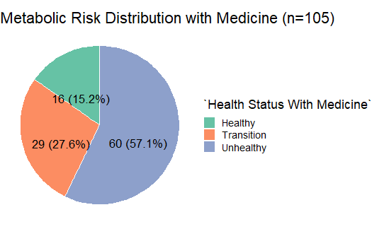

# Verificação de Healthy e Unhealthy, comparando os numeros.

Sem medicamentos temos H25, T 34 e UnH 46. Contando os medicamentos, temos 16H, 29 T e 60 Unhealth

| Health_Status | Nao | Sim |
| --- | --- | --- |
| Healthy | 18 | 7 |
| Transition | 24 | 10 |
| Unhealthy | 20 | 26 |

#tentando evitar distorções *inserir uma categoria intermediária “Controlled under medication” para diferenciar pessoas que usam remédio mas estão bem controladas, em vez de já irem direto para “Unhealthy”.*

*Proposta de Categorias* Healthy – Score total <= 1 sem uso de medicação

Controlled Medicated – Usa medicação, mas total_score_medicado ≤ 2 (parâmetros controlados)

Unhealthy – Score total ≥ 5 ou uso de medicação com score ≥ 3

```r
metadados_grupos_saude_binario <- metadados_grupos_saude_binario %>%
  mutate(
    Medication_Flag = ifelse((Metformin == "Sim" | Statins == "Sim" | antihypertensive == "1"), TRUE, FALSE),
    Health_Status_Med_Control = case_when(
      total_score_medicado <= 1 & !Medication_Flag ~ "Healthy",
      Medication_Flag & total_score_medicado <= 2 ~ "Controlled Medicated",
      !Medication_Flag & total_score_medicado >= 2 & total_score_medicado <= 4 ~ "Transition",
      total_score_medicado >= 5 ~ "Unhealthy",
      Medication_Flag & total_score_medicado >= 3 ~ "Unhealthy",
      TRUE ~ "Transition"
    )
  )
```

[output not shown]

Tabela de comparção entre categorias

| Health_Status | Controlled Medicated | Healthy | Transition | Unhealthy |
| --- | --- | --- | --- | --- |
| Healthy | 5 | 14 | 6 | 0 |
| Transition | 0 | 0 | 26 | 8 |
| Unhealthy | 0 | 0 | 1 | 45 |

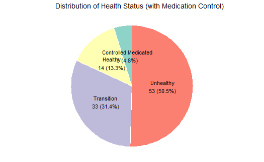

*#====================================================#* *Health Index desmembrado em eixos funcionais de saúde* *#====================================================#*

Criar eixos separados de risco metabólico (em vez de um índice único):

1. Eixo Glicêmico → Glicemia, HbA1c (e opcionalmente: insulina, HOMA-IR)
2. Eixo Cardiovascular → Pressão arterial, uso de anti-hipertensivos
3. Eixo Lipídico → Colesterol total, HDL, LDL, Triglicerídeos, uso de estatinas
4. Eixo Inflamatório → PCR, GGT, citocinas inflamatórias (IL-6, TNF, etc.) - **Como o eixo inflamatorio tem só 76 voluntarios, vou tira-lo dessa etapa. Vou cria-lo e fazer análises com eles separadas depois.**

Isso permite:

Identificar padrões distintos de transição.

Fazer análises multivariadas como PERMANOVA com maior clareza.

Visualizar melhor nos gráficos (ex: com gráficos ternários ou radar).

Ligar grupos bacterianos a tipos de risco (glicêmico, cardiovascular, etc).

#================

*Eixo Glicêmico → HbA1c_cat + High_Fasting_Glucose + Score_Glicemia*

*Eixo Cardiovascular → High_Blood_Pressure + Score_Hipertensao*

*Eixo Lipídico → TRIG_cat + COL_cat + HDL_cat + LDL_cat + Score_Colesterol*

Efeito da metformina (glicemia e lipídios) A metformina reduz glicose em jejum e HbA1c, e também promove redução moderada de LDL e triglicerídeos (~10‑15%) e aumento leve de HDL (~7 %)

Efeito das estatinas (lipídico e pressão) As estatinas são altamente eficazes em reduzir LDL (30–50 %) e triglicerídeos, além de aumentar HDL e reduzir inflamação (CRP) e ainda ter efeito leve na pressão arterial

Com isso, faz sentido que esses scores reflitam o impacto farmacológico nos três eixos.

Justificativa da inclusão dos scores *Score_Glicemia: captura risco residual glicêmico mesmo com medicação* — por isso faz parte do eixo glicêmico.

*Score_Hipertensao: mesmo com anti-hipertensivos, se a pressão continua alta, isso indica falha ou dependência.*

*Score_Colesterol: idem para lipídios — mesmo com estatinas, se as categorias de colesterol estão alteradas, isso indica risco residual.*

**Como soma para cada eixo funciona** Cada eixo é a soma de parâmetros clínicos normais/alterados + pontuação por uso de medicamento, refletindo:

O estado biológico atual (níveis de biomarcadores)

A dependência ou falha terapêutica (uso de medicação)

#*Calculo Eixos Ajustados*#

*GRAFICO TERNARIO (Usando proporção e gravidade/frequencia)*

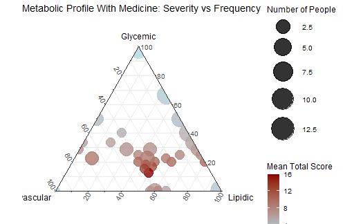

*GRAFICO RADAR*

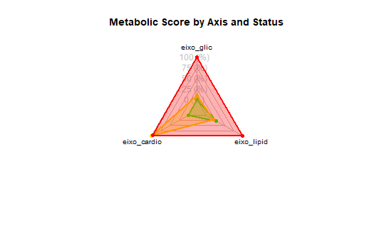

```r
# Inserir legenda dentro do gráfico
legend(
  x = 0.8, y = 0.8,                        # posição dentro do plot (ajuste conforme necessidade)
  legend = rownames(radar_df)[-c(1,2)],   # nomes dos grupos
  col = colors,
  pch = 16,
  bty = "n",
  pt.cex = 1.5,
  cex = 0.8
)
```

```
Error in (function (s, units = "user", cex = NULL, font = NULL, vfont = NULL,  :
  plot.new has not been called yet
```